# Impacts of sever weather events on public health and economics

Shadi

4/21/2020

## Synopsis

In the Second Project of Reprudicble research, we deal with the data from NOAA.This database contains data of major storms and weather events in US as well as the location, fatality , injuries, property and crop damages. In what follows are aim is to figure out which type of sever weather event has the most damage in terms of health and economics. To process this effect we need to transform and clean the data looking at the code book provide by NOAA there are 48 event type while when we look at the storm data set we face 985 event type this might happened because of the dictaion error or any other kind of human error. This would be a tedious work, one way to deal with this is to remove the events with zero fatality and damage. Afterward trying to fix the gramartical mistake. ALong this property damage exp and crop damage exp are charachter vector with variables 0_8,hH,KK,Mm,bB which respectivily shown 10,100,1000,10<sup>6,10</sup>9 this vectors should be substitue with their numerical values so that we could continue the analysis. Conducting the analysis we could conclude that the Tornado had the greatest health impact measured by the number of injuries and fatalities. Moreover, The analysis also shows that floods cause the greatest economic impact as measured by property damage and crop damage.

## Data Processing

Data has been download previously and unziped. directory would be setup where the data have been download and placed, and data loaded from the directory

```r
setwd("~/Desktop/test")
storm_data<-read.csv("repdata-data-StormData.csv")
```

The required package and libraries will be loaded

```r
library(dplyr)
```

```r
library(ggplot2)
```

On first Step of Processing data we take a look at the dimension and summaries of the data:

```r
dim(storm_data)
```

```
## [1] 902297     37
```

```r
str(storm_data)
```

```
## 'data.frame':    902297 obs. of  37 variables:
##  $ STATE__   : num  1 1 1 1 1 1 1 1 1 1 ...
##  $ BGN_DATE  : Factor w/ 16335 levels "1/1/1966 0:00:00",..: 6523 6523 4242 11116 2224 2224 2260 383 3980 3980 ...
##  $ BGN_TIME  : Factor w/ 3608 levels "00:00:00 AM",..: 272 287 2705 1683 2584 3186 242 1683 3186 3186 ...
##  $ TIME_ZONE : Factor w/ 22 levels "ADT","AKS","AST",..: 7 7 7 7 7 7 7 7 7 7 ...
##  $ COUNTY    : num  97 3 57 89 43 77 9 123 125 57 ...
##  $ COUNTYNAME: Factor w/ 29601 levels "","5NM E OF MACKINAC BRIDGE TO PRESQUE ISLE LT MI",..: 13513 1873 4598 10592 4372 10094 1973 23873 24418 4598 ...
##  $ STATE     : Factor w/ 72 levels "AK","AL","AM",..: 2 2 2 2 2 2 2 2 2 2 ...
##  $ EVTYPE    : Factor w/ 985 levels "   HIGH SURF ADVISORY",..: 834 834 834 834 834 834 834 834 834 834 ...
##  $ BGN_RANGE : num  0 0 0 0 0 0 0 0 0 0 ...
##  $ BGN_AZI   : Factor w/ 35 levels "","  N"," NW",..: 1 1 1 1 1 1 1 1 1 1 ...
##  $ BGN_LOCATI: Factor w/ 54429 levels ""," Christiansburg",..: 1 1 1 1 1 1 1 1 1 1 ...
##  $ END_DATE  : Factor w/ 6663 levels "","1/1/1993 0:00:00",..: 1 1 1 1 1 1 1 1 1 1 ...
##  $ END_TIME  : Factor w/ 3647 levels ""," 0900CST",..: 1 1 1 1 1 1 1 1 1 1 ...
##  $ COUNTY_END: num  0 0 0 0 0 0 0 0 0 0 ...
```

[output cut: 23 more lines]

Looking at data we see that we have 985 event type which is in contrast with the 48 event type we have in the provided data information from NOAA. This error might had happend because of human error. To deal with this error, In subseting I would remove the event with zero obserivation and then fix the gramatical mistakes.

There are two question to be answered so I need a sub dataset to answer each. I will name them health dataset and economics dataset

1. Starting with subset for the health analysis.

```r
health<- subset(storm_data,!storm_data$FATALITIES == 0 & !storm_data$INJURIES ==
    0 , select=c(EVTYPE, FATALITIES, INJURIES))
```

now we are trying to fix the error on the events

```r
health$EVTYPE <- toupper(health$EVTYPE)
health$EVTYPE <- gsub("^EXTREME WIND ?CHILL$|^(EXTENDED|EXTREME|RECORD)? COLDS?$","EXTREME COLD/WIND CHILL", health$EVTYPE)

health$EVTYPE <- gsub("^FLOODS?.*|FLOOD(ING)?S?$","FLOOD", health$EVTYPE)
health$EVTYPE <- gsub("^HEAVY SURF(/HIGH SURF)?.*$|^(ROUGH|HEAVY) SEAS?.*|^ROUGH SURF.*|^HIGH WIND AND SEAS$|^HIGH SURF.*",
                                   "HIGH SURF", health$EVTYPE)

health$EVTYPE <- gsub("^HEAT WAVES?$|^WARM WEATHER$", "HEAT", health$EVTYPE)
health$EVTYPE <- gsub("^GLAZE.*|^FREEZING (RAIN|DRIZZLE|RAIN/SNOW|SPRAY$)$|^WINTER WEATHER MIX$|^LIGHT SNOW$|^SLEET.*",
                                    "SLEET", health$EVTYPE)

health$EVTYPE <- gsub("^RAIN/SNOW$|^(BLOWING|HEAVY||ICE AND|RECORD)? ?SNOWS?.*", "HEAVY SNOW", health$EVTYPE)
health$EVTYPE <- gsub("^EXCESSIVE RAINFALL$|^RAIN.*|^(HEAVY|HVY)? (RAIN|MIX|PRECIPITATION).*", "HEAVY RAIN", health$EVTYPE)
health$EVTYPE <- gsub("^WINDCHILL$|^COLD.*", "COLD/WIND CHILL", health$EVTYPE)
health$EVTYPE <- gsub("^FROST[/\\]FREEZE$|^FROST$|^(DAMAGING)? ?FREEZE$|^HYP[OE]R?THERMIA.*|^ICE$|^(ICY|ICE) ROADS$|^BLACK ICE$|^ICE ON ROAD$",
                      "FROST/FREEZE", health$EVTYPE)
health$EVTYPE <- gsub("^FOG.*", "FREEZING FOG", health$EVTYPE)
health$EVTYPE <- gsub("^HEAT WAVE DROUGHT?$", "HEAT", health$EVTYPE)
health$EVTYPE <- gsub("^HIGH WIND.*", "HIGH WIND", health$EVTYPE)
health$EVTYPE <- gsub("^STRONG WIND.*", "STRONG WIND", health$EVTYPE)
health$EVTYPE <- gsub("^RIP CURRENT.*", "RIP CURRENT", health$EVTYPE)
health$EVTYPE <- gsub("^WINTER STORM.*", "WINTER STORM", health$EVTYPE)
health$EVTYPE <- gsub("^WINTER WEATHER/MIX*", "WINTER WEATHER", health$EVTYPE)

health$EVTYPE <- gsub("TSTM|THUNDERSTORMS?", "THUNDERSTORM", health$EVTYPE)
health$EVTYPE <- gsub("^TH?UN?DEE?RS?TO?RO?M ?WIND.*|^(SEVERE )?THUNDERSTORM$|^WIND STORM$|^(DRY )?MI[CR][CR]OBURST.*|^THUNDERSTORMW$",
                      "THUNDERSTORM WIND", health$EVTYPE)
health$EVTYPE <- gsub("^WILD/FOREST FIRE$|^(WILD|BRUSH|FOREST)? ?FIRES?$", "WILDFIRE", health$EVTYPE)
```

Now that our health data is ready we could start to find the fatality per event, to do so I am aslo adding another variable which is sum of the FATALITIES and INJURIES I will call it TOTAl_Health_Damage

```r
health$TOTAl_Health_Damage<-health$FATALITIES+health$INJURIES
```

Our health data is now ready for the further analysis, before starting with the analysis for health data we are going to do the same thing for the economic data, when we have both data set ready we could continue with the analysis.

2. Moving to economic sub data set

Subseting the data set which dosen’t have Zero obeservation

```r
Econ_damage<- subset(storm_data, !PROPDMG==0 & !CROPDMG==0 , select=c(EVTYPE, PROPDMG, PROPDMGEXP,CROPDMG,CROPDMGEXP))
```

Fixing the gramatical mistakes

```r
Econ_damage$EVTYPE <- toupper(Econ_damage$EVTYPE)

Econ_damage$EVTYPE <- gsub("^EXTREME WIND ?CHILL$|^(EXTENDED|EXTREME|RECORD)? COLDS?$","EXTREME COLD/WIND CHILL", Econ_damage$EVTYPE)

Econ_damage$EVTYPE <- gsub("^FLOODS?.*|FLOOD(ING)?S?$","FLOOD", Econ_damage$EVTYPE)
Econ_damage$EVTYPE <- gsub("^HEAVY SURF(/HIGH SURF)?.*$|^(ROUGH|HEAVY) SEAS?.*|^ROUGH SURF.*|^HIGH WIND AND SEAS$|^HIGH SURF.*",
                      "HIGH SURF", Econ_damage$EVTYPE)

Econ_damage$EVTYPE <- gsub("^HEAT WAVES?$|^WARM WEATHER$", "HEAT", Econ_damage$EVTYPE)
Econ_damage$EVTYPE <- gsub("^GLAZE.*|^FREEZING (RAIN|DRIZZLE|RAIN/SNOW|SPRAY$)$|^WINTER WEATHER MIX$|^LIGHT SNOW$|^SLEET.*",
                      "SLEET", Econ_damage$EVTYPE)
Econ_damage$EVTYPE <- gsub("^RAIN/SNOW$|^(BLOWING|HEAVY||ICE AND|RECORD)? ?SNOWS?.*", "HEAVY SNOW", Econ_damage$EVTYPE)
Econ_damage$EVTYPE <- gsub("^EXCESSIVE RAINFALL$|^RAIN.*|^(HEAVY|HVY)? (RAIN|MIX|PRECIPITATION).*", "HEAVY RAIN", Econ_damage$EVTYPE)
Econ_damage$EVTYPE <- gsub("^WINDCHILL$|^COLD.*", "COLD/WIND CHILL", Econ_damage$EVTYPE)
Econ_damage$EVTYPE <- gsub("^FROST[/\\]FREEZE$|^FROST$|^(DAMAGING)? ?FREEZE$|^HYP[OE]R?THERMIA.*|^ICE$|^(ICY|ICE) ROADS$|^BLACK ICE$|^ICE ON                            ROAD$","FROST/FREEZE", Econ_damage$EVTYPE)
Econ_damage$EVTYPE <- gsub("^FOG.*", "FREEZING FOG", Econ_damage$EVTYPE)
Econ_damage$EVTYPE <- gsub("^HEAT WAVE DROUGHT?$", "HEAT", Econ_damage$EVTYPE)
Econ_damage$EVTYPE <- gsub("^HIGH WIND.*", "HIGH WIND", Econ_damage$EVTYPE)
Econ_damage$EVTYPE <- gsub("^STRONG WIND.*", "STRONG WIND", Econ_damage$EVTYPE)
Econ_damage$EVTYPE <- gsub("^RIP CURRENT.*", "RIP CURRENT", Econ_damage$EVTYPE)
Econ_damage$EVTYPE <- gsub("^WINTER STORM.*", "WINTER STORM", Econ_damage$EVTYPE)
Econ_damage$EVTYPE <- gsub("^WINTER WEATHER/MIX*", "WINTER WEATHER", Econ_damage$EVTYPE)

Econ_damage$EVTYPE <- gsub("TSTM|THUNDERSTORMS?", "THUNDERSTORM", Econ_damage$EVTYPE)
Econ_damage$EVTYPE <- gsub("^TH?UN?DEE?RS?TO?RO?M ?WIND.*|^(SEVERE )?THUNDERSTORM$|^WIND STORM$|^(DRY )?MI[CR][CR]OBURST.*|^THUNDERSTORMW$",
                      "THUNDERSTORM WIND", Econ_damage$EVTYPE)
Econ_damage$EVTYPE <- gsub("^WILD/FOREST FIRE$|^(WILD|BRUSH|FOREST)? ?FIRES?$", "WILDFIRE", Econ_damage$EVTYPE)
Econ_damage$EVTYPE <- gsub("^FLOODS?.*|^URBAN/SML STREAM FLD$|^(RIVER|TIDAL|MAJOR|URBAN|MINOR|ICE JAM|RIVER AND STREAM|URBAN/SMALL STREAM)?
                      FLOOD(ING)?S?$|^HIGH WATER$|^URBAN AND SMALL STREAM FLOODIN$|^DROWNING$|^DAM BREAK$", "FLOOD", Econ_damage$EVTYPE)
Econ_damage$EVTYPE <- gsub("^FLASH FLOOD.*|^RAPIDLY RISING WATER$", "FLASH FLOOD", Econ_damage$EVTYPE)

Econ_damage$EVTYPE <- gsub("^TORNADO.*", "TORNADO", Econ_damage$EVTYPE)
Econ_damage$EVTYPE <- gsub("^WHIRLWIND$|^GUSTNADO$|^TORNDAO$", "TORNADO", Econ_damage$EVTYPE)

Econ_damage$EVTYPE <- gsub("^HURRICANE.*", "HURRICANE/TYPHOON", Econ_damage$EVTYPE)
Econ_damage$EVTYPE <- gsub("^TYPHOON", "HURRICANE/TYPHOON", Econ_damage$EVTYPE)

Econ_damage$EVTYPE <- gsub("^TROPICAL STORM.*", "TROPICAL STORM", Econ_damage$EVTYPE)

Econ_damage$EVTYPE <- gsub("^(SMALL )?HAIL.*", "HAIL", Econ_damage$EVTYPE)
```

if we take a look at data we see that for both PROPDMGEXP and CROPDMGEXP we have the unit written as H,K,B we want to fix that to it’s numerical value as we remove the values that we didn’t have any observation now we don’t have any values for ? and - so we could skip them in our conversion.

```r
Econ_damage$PROPDMGEXP<-gsub("[+]",1, Econ_damage$PROPDMGEXP)
Econ_damage$PROPDMGEXP<-gsub("[0-8]",10, Econ_damage$PROPDMGEXP)
Econ_damage$PROPDMGEXP<-gsub("[hH]",100, Econ_damage$PROPDMGEXP)
Econ_damage$PROPDMGEXP<-gsub("[kK]",1000, Econ_damage$PROPDMGEXP)
Econ_damage$PROPDMGEXP<-gsub("[mM]",1000000, Econ_damage$PROPDMGEXP)
Econ_damage$PROPDMGEXP<-gsub("[bB]",1000000000, Econ_damage$PROPDMGEXP)
Econ_damage$CROPDMGEXP<-gsub("[+]",1, Econ_damage$CROPDMGEXP)
Econ_damage$CROPDMGEXP<-gsub("[0-8]",10, Econ_damage$CROPDMGEXP)
Econ_damage$CROPDMGEXP<-gsub("[hH]",100, Econ_damage$CROPDMGEXP)
Econ_damage$CROPDMGEXP<-gsub("[kK]",1000, Econ_damage$CROPDMGEXP)
Econ_damage$CROPDMGEXP<-gsub("[mM]",1000000, Econ_damage$CROPDMGEXP)
Econ_damage$CROPDMGEXP<-gsub("[bB]",1000000000, Econ_damage$CROPDMGEXP)
Econ_damage$PROPDMGEXP<-as.numeric(Econ_damage$PROPDMGEXP)
Econ_damage$CROPDMGEXP<-as.numeric(Econ_damage$CROPDMGEXP)
Econ_damage$PROPDMGEXP[is.na(Econ_damage$PROPDMGEXP)]<-0
Econ_damage$CROPDMGEXP[is.na(Econ_damage$CROPDMGEXP)]<-0
 Econ_damage$PROPDMGEXP<-as.numeric(Econ_damage$PROPDMGEXP)
Econ_damage$CROPDMGEXP<-as.numeric(Econ_damage$CROPDMGEXP)
```

define two variable total property damage and total crop damage

```r
Econ_damage$totalprobdmg<-Econ_damage$PROPDMG*Econ_damage$PROPDMGEXP
Econ_damage$totalcrobdmg<-Econ_damage$CROPDMG*Econ_damage$CROPDMGEXP
Econ_damage$totaldamage<-Econ_damage$totalprobdmg+Econ_damage$totalcrobdmg
```

Now are economics data set is also ready for the analysis.

## Results

First we want to see the result for the first question health to do so we start by grouping the fatalitity,injuries and total harm per event

```r
 final_health <- health %>% group_by(EVTYPE) %>% summarise_all(list(sum))
```

Then we could do either sort the data or we could find the max value and then look at the event type for that specific max value. we will do both way.

```r
final_health[which.max(final_health$FATALITIES),]
```

```
## # A tibble: 1 x 4
##   EVTYPE  FATALITIES INJURIES TOTAl_Health_Damage
##   <chr>        <dbl>    <dbl>               <dbl>
## 1 TORNADO       5227    60187               65414
```

```r
final_health[which.max(final_health$INJURIES),]
```

```
## # A tibble: 1 x 4
##   EVTYPE  FATALITIES INJURIES TOTAl_Health_Damage
##   <chr>        <dbl>    <dbl>               <dbl>
## 1 TORNADO       5227    60187               65414
```

```r
final_health[which.max(final_health$TOTAl_Health_Damage),]
```

```
## # A tibble: 1 x 4
##   EVTYPE  FATALITIES INJURIES TOTAl_Health_Damage
##   <chr>        <dbl>    <dbl>               <dbl>
## 1 TORNADO       5227    60187               65414
```

or

```r
Health_Result<-final_health[order(final_health$TOTAl_Health_Damage,decreasing =TRUE),]
final_health[order(final_health$FATALITIES,decreasing =TRUE),]
```

```
## # A tibble: 48 x 4
##    EVTYPE            FATALITIES INJURIES TOTAl_Health_Damage
##    <chr>                  <dbl>    <dbl>               <dbl>
##  1 TORNADO                 5227    60187               65414
##  2 EXCESSIVE HEAT           402     4791                5193
##  3 LIGHTNING                283      649                 932
##  4 THUNDERSTORM WIND        281      832                1113
##  5 FLASH FLOOD              171      641                 812
##  6 HIGH WIND                117      355                 472
##  7 FLOOD                    109     2685                2794
##  8 HEAT                      99     1704                1803
##  9 WINTER STORM              96      631                 727
## 10 RIP CURRENT               82      154                 236
## # … with 38 more rows
```

```r
final_health[order(final_health$INJURIES,decreasing =TRUE),]
```

```
## # A tibble: 48 x 4
##    EVTYPE            FATALITIES INJURIES TOTAl_Health_Damage
##    <chr>                  <dbl>    <dbl>               <dbl>
##  1 TORNADO                 5227    60187               65414
##  2 EXCESSIVE HEAT           402     4791                5193
##  3 FLOOD                    109     2685                2794
##  4 ICE STORM                 35     1720                1755
##  5 HEAT                      99     1704                1803
##  6 HURRICANE/TYPHOON         32     1219                1251
##  7 THUNDERSTORM WIND        281      832                1113
##  8 BLIZZARD                  48      718                 766
##  9 LIGHTNING                283      649                 932
## 10 FLASH FLOOD              171      641                 812
## # … with 38 more rows
```

for economics impact we do the same analysis

```r
Final_econ <- Econ_damage %>% group_by(EVTYPE) %>% summarise_all(list(sum))
```

for finding the event with maximum damage :

```r
Final_econ[order(Final_econ$totalprobdmg,decreasing =TRUE),]
```

```
## # A tibble: 39 x 8
##    EVTYPE PROPDMG PROPDMGEXP CROPDMG CROPDMGEXP totalprobdmg totalcrobdmg
##    <chr>    <dbl>      <dbl>   <dbl>      <dbl>        <dbl>        <dbl>
##  1 FLOOD  157740.    2.38e 9 155839.  276283000 122104491650   4180041050
##  2 HURRI…  12258.    1.01e10  11405. 1063027000  37089803000   5333067800
##  3 RIVER…   2074.    1.01e 9   3977. 1006013000   5185675000   5056759000
##  4 TORNA… 163253.    1.17e 9  91075.   71104030   3587292780    401216300
##  5 FLASH… 213448.    2.64e 8 179451.  151951000   3260763544   1393126400
##  6 HAIL   208366.    1.55e 8 384828.  378084000   1960939240   1879129150
##  7 THUND… 245160.    1.57e 8 170402.  184915080   1776592100   1058705150
##  8 HIGH …  23351.    6.51e 7  19810.   45155000   1511991200    643095650
##  9 WILDF…   8236.    1.02e 9   4619.   19052000   1479523000    202631100
## 10 TROPI…   9271.    2.40e 7   5154.   26031000    868880400    468210000
## # … with 29 more rows, and 1 more variable: totaldamage <dbl>
```

```r
Final_econ[order(Final_econ$totalcrobdmg,decreasing =TRUE),]
```

```
## # A tibble: 39 x 8
##    EVTYPE PROPDMG PROPDMGEXP CROPDMG CROPDMGEXP totalprobdmg totalcrobdmg
##    <chr>    <dbl>      <dbl>   <dbl>      <dbl>        <dbl>        <dbl>
##  1 HURRI…  12258.    1.01e10  11405. 1063027000  37089803000   5333067800
##  2 RIVER…   2074.    1.01e 9   3977. 1006013000   5185675000   5056759000
##  3 ICE S…   1789.    4.02e 6   1689. 1004019000     86504500   5022113500
##  4 FLOOD  157740.    2.38e 9 155839.  276283000 122104491650   4180041050
##  5 HAIL   208366.    1.55e 8 384828.  378084000   1960939240   1879129150
##  6 FLASH… 213448.    2.64e 8 179451.  151951000   3260763544   1393126400
##  7 DROUG…   2063.    2.40e 7   7001.   27012000    232732000   1231755000
##  8 THUND… 245160.    1.57e 8 170402.  184915080   1776592100   1058705150
##  9 HIGH …  23351.    6.51e 7  19810.   45155000   1511991200    643095650
## 10 EXCES…    170     1.00e 3    492.    1000000       170000    492400000
## # … with 29 more rows, and 1 more variable: totaldamage <dbl>
```

```r
Econ_Result<-Final_econ[order(Final_econ$totaldamage,decreasing =TRUE),]
```

or

```r
Final_econ[which.max(Final_econ$totalprobdmg),]
```

```
## # A tibble: 1 x 8
##   EVTYPE PROPDMG PROPDMGEXP CROPDMG CROPDMGEXP totalprobdmg totalcrobdmg
##   <chr>    <dbl>      <dbl>   <dbl>      <dbl>        <dbl>        <dbl>
## 1 FLOOD  157740. 2378179000 155839.  276283000 122104491650   4180041050
## # … with 1 more variable: totaldamage <dbl>
```

```r
Final_econ[which.max(Final_econ$totalcrobdmg),]
```

```
## # A tibble: 1 x 8
##   EVTYPE PROPDMG PROPDMGEXP CROPDMG CROPDMGEXP totalprobdmg totalcrobdmg
##   <chr>    <dbl>      <dbl>   <dbl>      <dbl>        <dbl>        <dbl>
## 1 HURRI…  12258.    1.01e10  11405. 1063027000  37089803000   5333067800
## # … with 1 more variable: totaldamage <dbl>
```

looking at the result we see that flood has maximum damage on the property and Thyphon has the maximum damage on crops looking the totol economic damage flood is the winner.

Just to make the result clear we take a look at the graph for each of the questions

## Figures

graph for the top total health damage :

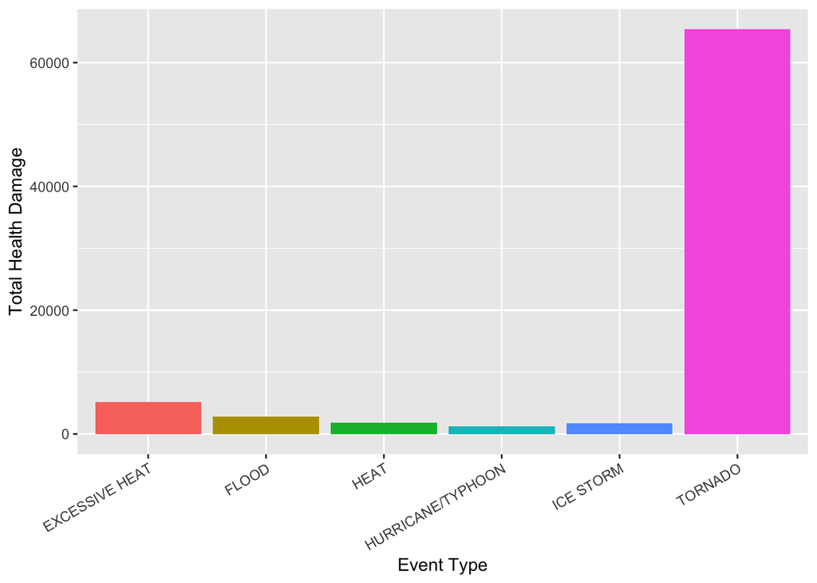

```r
ggplot() + geom_bar(data = head(Health_Result), aes(x = EVTYPE, y = TOTAl_Health_Damage, fill = interaction(TOTAl_Health_Damage,
         EVTYPE)), stat = "identity", show.legend = F) + theme(axis.text.x = element_text(angle = 30,
                                         hjust = 1)) + xlab("Event Type") + ylab("Total Health Damage")
```

graph for total economic damage :

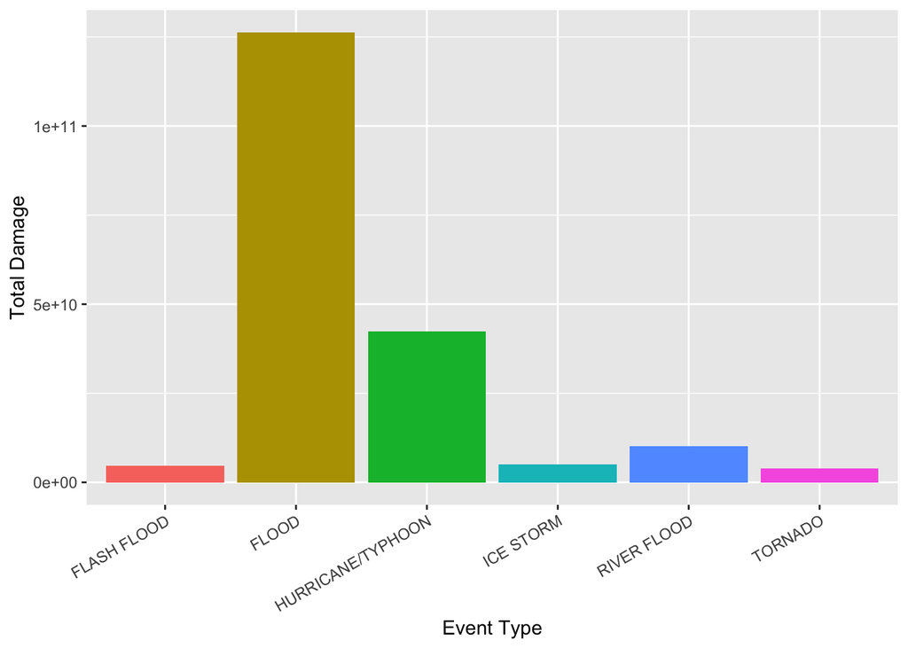

```r
ggplot() + geom_bar(data = head(Econ_Result), aes(x = EVTYPE, y = totaldamage, fill = interaction(totaldamage,
         EVTYPE)), stat = "identity", show.legend = F) + theme(axis.text.x = element_text(angle = 30,
                                         hjust = 1)) + xlab("Event Type") + ylab("Total Damage")
```